# MA331-Report: 2211466

TED Talks by Speaker Nick Sears and Speaker Dame Stephanie Shirley

NAYAK, VAIBHAV

## 1. Introduction

This project aims to conduct a text analysis of two TED Talks delivered by Nick Sears and Dame Stephanie Shirley, respectively. Nick Sears’ TED Talk, delivered in 2007, is titled “Demo: The Orb,” while Dame Stephanie Shirley’s TED Talk, delivered in 2015, is titled “Why do ambitious women have flat heads?”.Nick Sears shows how a fully volumetric display can produce a sphere of light with just 256 LEDs. His invention is a modernization of Buckminster Fuller’s 1962 Geoscope, a geodesic sphere with a 200-foot circumference that could show world data and trends through animations.Dame Stephanie Shirley’s TED Talk is about her experiences as a successful businesswoman in a male-dominated industry, and explores why women who are ambitious and successful may face societal pressures to conform and downplay their achievements. The project seeks to answer questions such as number of different facets, the themes they covered, the sentiment they used, and the terms they used most frequently. Additionally, the project will use odds ratio analysis & sentimental analysis to identify the words most strongly connected to each speaker’s speeches, with the ultimate goal of gaining a better understanding of Nick Sears’ and Dame Stephanie Shirley’s viewpoints and ideas.

## 2. Methods

To achieve the Analysis objectives following methods are followed:

### 2.1 Load the Data

The ted_talks has many speakers data. As per report requirement, data related to above mentioned speaker is filtered using filter function.Later, digits and unwanted spaces are removed using string function, So that only text remains for analysis.

### 2.2 Tidying and Tokenisation

Tokenisation is the process of breaking apart text into individual tokens, a meaningful unit of text for analysis. Tidying is the process of arranging the data into a specific structure: Each variable is a column, Each observation is a row, Each type of observation unit is a table.

### 2.3 Stop words Removal and Identification of top words for certain speakers

Words such as ‘the’, ‘and’, and ‘to’ are NOT interesting for a text analysis. Such words are called stop words. Often the best choice is to remove them. The tidytext package provides access to stop word lexicons (using get_stopwords()), through whic some of the dplyr’s functions can be used in analysis, e.g., anti_join() to remove the stop words. Use the anti_join() function to remove the stopwords from the tokenised TED talks data. Following the removal of the stopwords, Using the dplyr’s count() to count up words from the TED talk given by both speakers.Sorting the words with the most frequent terms at the top.

### 2.4 Visualisation of top words for certain speaker

Following Calculation top words for certain speaker, Now the top words vs count is displayed. The top words are calculated,so that some patterns,Unique feature,tone can be predicted. Speaker1 is Nick Sears and Speaker2 is Dame Stephanie Shirley.

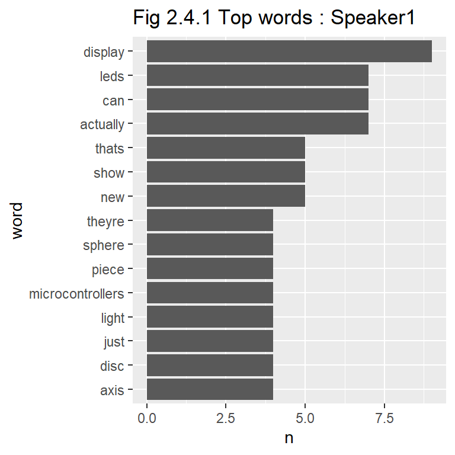

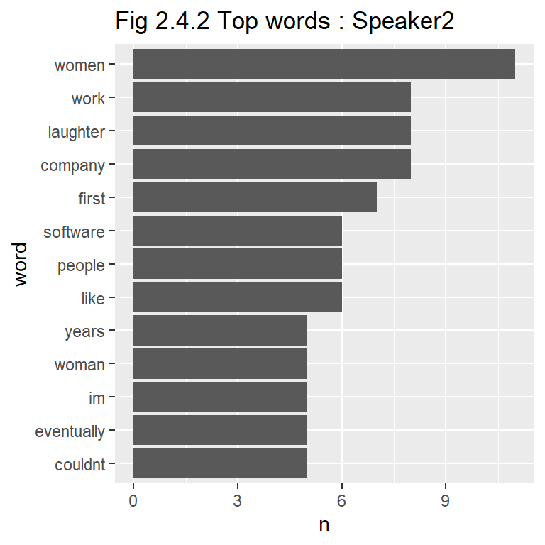

As shown in above Fig 2.4.1, The most words used by Nick sears are display,leds,sphere,microcontollers,light, axis,disc. Some stories that can be observed based on these words are: Speaker1 is working on Led display technology, word “micro controllers” tells that speaker1 uses this device for his work ,words “sphere” ,“axis” , disc suggest that speaker1 is developing led displays with different shapes or movements. As shown in above Fig 2.4.2, The most words used by Dame Stephanie Shirley are women, company, software, first, year. Some stories that can be observed based on these words are: Speaker2 is focusing on women empowerment, words “company”,“software”,“first” tells that speaker2’s interest in business,Technology & innovation ,word “years” , suggest that speaker2 is working for long time in mentioned field.

### 2.5 Comparison between speaker using Visualization.

After counting words from the talks of Nick Sears and Dame Stephanie Shirley.From the package ggrepel to plot words of DameStephanieShirley_words on the x-axis against words of NickSears_words on the y-axis.Comparing the word usage patterns between two speakers and identifying the words that are used more frequently by one speaker compared to the other.

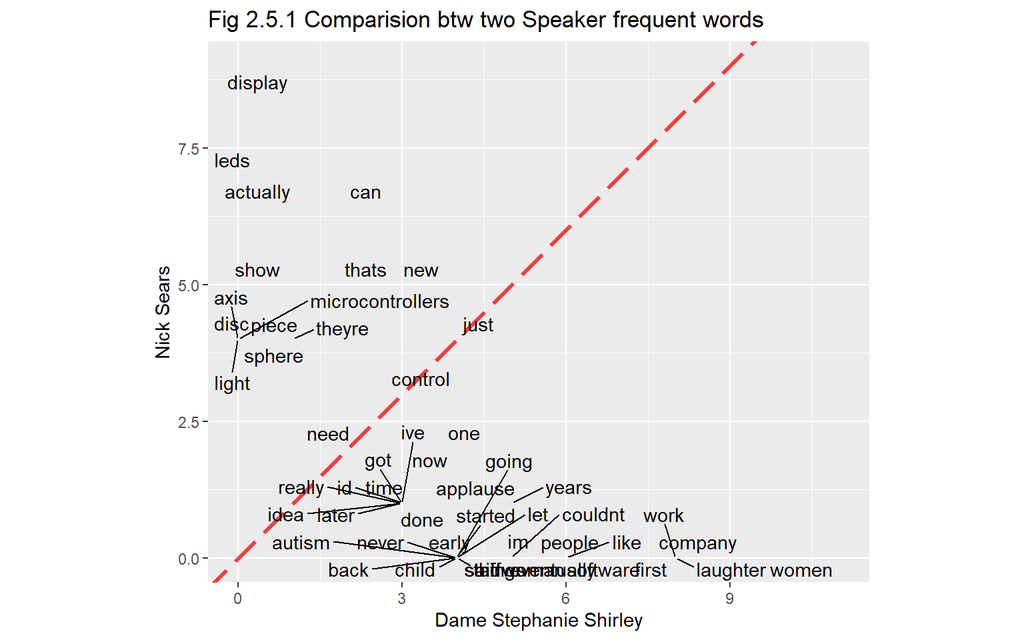

As shown above in Fig 2.5.1, Both speaker text has “applause”, which indicates they received applause during speech,But Dame Stephanie shirley received more applause compared to Nick sears .Henceforth applause word is only visible towards the same speaker.Both speakers used word “just” four times, but in different contexts.Word “just” can predict many things like speaker may try to keep it simple to all or try to mean they are not a expertise in that field.But we cannot predict or conclude without considering the speakers context and intentions.Both speaker have used “years” ,which may mean as their experiences or passage of time.

## 3. Results

### 3.1 Sentimental analysis using Bing Lexicon

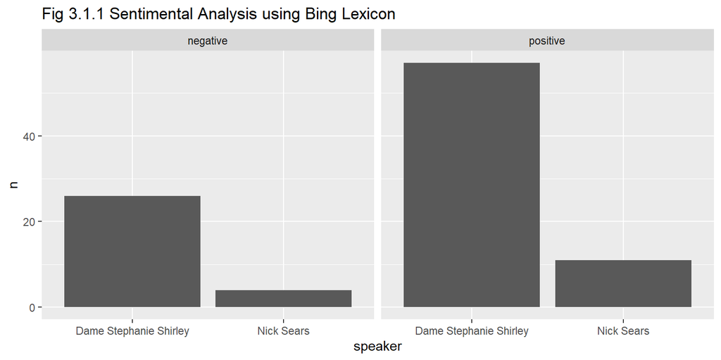

As shown in Fig 3.1.1, , observation can be divided as 3 parts as follows: 1.In both negative and positive sentiment, Dame Stephanie Shirley has higher value compared to Nick sears.2.Dame Stephanie Shirley, has higher value of positive sentiment compared to negative sentiment.3.Also Nick sears, has higher value of positive sentiment compared to negative sentiment. This implies that Dame Stephanie Shirley’s Ted presentation may have gotten greater audience participation and response than Nick Sears’ Ted talk. Overall, the results indicate that the audience generally had a more favorable perception of both speakers than a negative one. It’s crucial to remember that sentiment analysis has its limitations and might not always fully reflect the complexity of human emotions and viewpoints. In order to thoroughly comprehend the audience’s response to the Ted speeches, it may be necessary to proceed with caution before drawing any conclusions from this data.

### 3.2 Odds Ratio

For each word, it tells in which speakers talk the word is more likely to occur. Analysis uses the odds ratio summary statistic (referred to as OR) for quantifying these comparisons. To determine which words are more likely to be connected to a poistive or negative sentiment, sentiment analysis uses odds ratio. The underlying feelings and thoughts stated in the text can be better understood as a result.

Table 3.2.1 Sentiment Analysis Results using nrc Lexicon

| Sentiment | Dame Stephanie Shirley | Nick Sears | OR | log_OR |
| --- | --- | --- | --- | --- |
| trust | 44 | 18 | 2.0016234 | 0.6939585 |
| positive | 90 | 24 | 1.2160000 | 0.1955668 |
| negative | 24 | 6 | 1.0808824 | 0.0777777 |
| anticipation | 49 | 9 | 0.7601256 | -0.2742716 |
| joy | 45 | 8 | 0.7353535 | -0.3074039 |
| surprise | 24 | 4 | 0.7000000 | -0.3566749 |
| fear | 14 | 2 | 0.6031746 | -0.5055486 |
| sadness | 14 | 2 | 0.6031746 | -0.5055486 |
| anger | 8 | 1 | 0.5308219 | -0.6333287 |
| disgust | 6 | 0 | 0.0000000 | -Inf |